# AMS Data1

## Assignment 1: Water

###### © Group 3 - Lena Gerstmans, Henrike Beckefeld & Tess van den Berg

##### **Link back to our webstite:** *https://tessvdberg.github.io/thisisgroup3.github.io/*

## Paralympics.

Paris is hosting the Paralympics in 2024. One of the events at the Paralympics is an open water swimming event in the Seine (apparently the water is clean or so the French say). Since the City of Amsterdam thinks it is better than Paris, they want to host an event before the Paralympics, snubbing the Parisians. The idea is to host a 5km. open water swimming event through the canals of Amsterdam. You are asked by the municipality of Amsterdam to advise on the feasibility of the event from the perspective of the safety of the partaking athletes from an environmental perspective. The event is going to be hosted in May.

#### Questions about Water Pollution.

- What is the pollution level of the canals and is there data from all the canals?
- Which datasets are of use for giving a proper advice to the municipality?
- What type of data format is the information you found stored in?
- Is the data stored numerical?
- How can you open this in python?

#### Answers.

Finding public data on water quality for swimming in the canals of Amsterdam was extremely difficult. In order for water to be physically healthy for swimming, the pH, E. coli bacteria level, clarity, and cyanobacteria level needs to be monitored and on a certain level. Most important factors for Amsterdam were E. Coli and cyanobacteria (Van der Meulen, 2023). If the paralymics will take place, the whole canal should be dredged for safety of the swimmers. Hence, the current clarity level is of little importance for this research.

In 2017, a civilian research was done in collaboration with Deltares, WUR, AMS and Waternet, named ‘Het Schone Water Experiment’. Unfortunately, the website expired and data is no longer publicly available. Our group contacted Suzanne van der Meulen, who was the first author in the article of Deltares (Van der Meulen et al, 2018). Van der Meulen shared the results of the experiment with us, as well as the datasheet of her PHD, partly focussing on water quality in Amsterdam for recreational purposes.

The datasheet of ‘Het Schone Water Experiment’ cannot provide us with sufficient information on water quality for swimming, as little E. Coli measurements and no cyanobacteria measurements were done. The benefit of this datasheet, however, is that it covers a large range of Amsterdam. The datasheet of the PHD of van der Meulen (2023) covers only 13 locations in Amsterdam, not solely canals. She received data from Waternet, and transformed this. More locations were not possible. The benefit of this datasheet is that E. coli and Cyanobacteria are the 95th percentile on increasing values, meaning that the measurement is not impacted by an outlier, as measurements were taken over time. Measurements are more vulnerable for outliers when only measuring once (as seen in ‘Het schone water experiment).

Hence, in our advise to the muncipality we would stress that the primary risks associated with swimming in the urban canal are fecal contamination (indicated by E. coli bacteria), and the presence of potentially toxin-producing cyanobacteria. This needs to be measured intensively over the course of a number of years in order to calculate the 95th percentile. Therefore, the municipality should collaborate closely with WaterNet to use their existing data and set up new measuring points. Only in this way, an estimation can be made on the route.

Taking into account the yearly event 'Amsterdam City Swim', it is also advised to build further upon their swimming route by taking it as a start or ending point. The longest swim route in this event is 2.1 KM from the Keizersgracht to the Marine Terraine. In this way, less 'new' investigation work is required: only 2.9 km more. If this is not feasible, it can be decided to make a 'two-way' route. g.The data of Van der Meulen and 'Het Schone Water Experiment cannot be used in deciding the swimming, as explained above. However, theoretically if we could use this data this is how we would open it in python and see what the highest and lowest levels of E. Coli and cyanobacteria are in the water.

When looking at both datasheets, eets, data is stored numerical and saved as .xls (excel). This is easiest to read in the Panda library.

```python
import pandas as pd
excelfile = 'C:/Users/lgers/Documents/VanderMeulen.xlsx'
df = pd.read_excel(excelfile)
column_name1 = 'E. coli [cfu/100ml]'
column_name2 = 'Cyanobacteria [ug/L]'
min_value1 = df[column_name1].min()
max_value1 = df[column_name1].max()
min_value2 = df[column_name2].min()
max_value2 = df[column_name2].max()

print(f"Minimum value in {column_name1} : {min_value1}")
print(f"Maximum value in {column_name1} : {max_value1}")
print(f"Minimum value in {column_name2} : {min_value2}")
print(f"Maximum value in {column_name2} : {max_value2}")
```

```
Minimum value in E. coli [cfu/100ml] : 88.49999999999997
Maximum value in E. coli [cfu/100ml] : 12450.0
Minimum value in Cyanobacteria [ug/L] : 0.0
Maximum value in Cyanobacteria [ug/L] : 320.15
```

### Questions about Water Transport.

- The event can’t have an impact on commercial water transport.
- It would be appreciated if the event also has small impact on the routes of the canal boats.

#### Answers.

The IJ is not possible to include in the swimming route, since the ferry needs to continue to operate. In addition, the current is strong in the IJ.

Regarding commercial transport, the routes can be seen on pdok (https://www.pdok.nl/atom-downloadservices/-/article/vaarweg-informatie-nederland-vin-). The format of this data is gpkg. Commercial transport passes through the Amstel river and from the Amstel river to the Westerdok. This can be opend in geopandas. To disrupt the water transport as little as possible, one should also look at the disembarking points. This can be retrieved from https://maps.amsterdam.nl/varen/. This data can be downloaded in csv and json, which can be opend with pandas and json in python. The data is human readable.

Above explains why it cannot be in the larger canals/rivers of Amsterdam.

Regarding the passing of boats in the canals in the city centre, no raw data could be found on the number and types of boats. Luckily, the municipality of Amsterdam started the project ‘Digitale gracht Amsterdam’ (Gemeente Amsterdam, 2021). This city-wide water-traffic monitoring system measures analyses the watermovement of transport-, passenger, and prive/recreational boats. It's an innovative example of a smart system.

The sensors scan the chip in the vignette of the boat, ensuring anonymity while monitoring water movements. By combining multiple vignette readers, the routes of boats can be determined. The government already creates reports on these movements. This data stored in their dashboard is not publicly available, only the graphs and maps they publish in their reports. Hence, the advice would be to either share the data on routes of commercial shipping and canal boats so we can propose the best swimming location and route, or decide themselves and then share the information with us. Below you can see an example of a map made by the municipality on the number of passages in the canals of Amsterdam. The raw data to create this map could not be found.

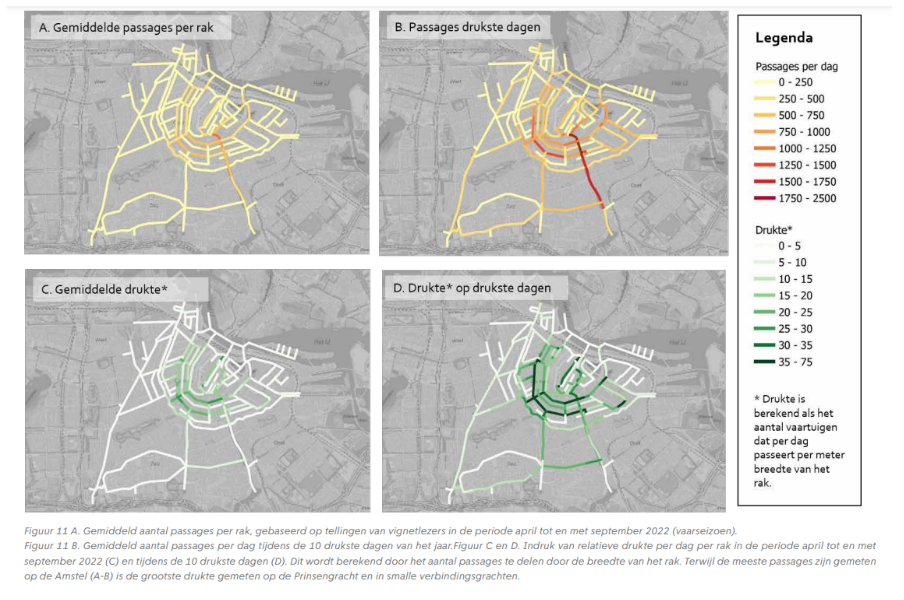

The municipality of Amsterdam was contacted to ask for the raw data of ‘The Digitale Gracht’ project. Unfortunatelly, we did not receive a response.

(the cell below was transfered to 'raw' (using Esc r) because this is no real data):

*#measurements of boat types per hour:* *sensor1 = 'type1', 'type2', 'type2', 'type1', 'type1', 'type3', 'type3', 'type2', 'type2', 'type1', 'type1', 'type3', 'type1'* *sensor2 = similar to above*

*#to see how many boats per hour: print(len(sensor1))*

*#to see how many boats per type per hour: count_of_type1 = sensor1.count('type1') print(f"The number of type 1 boats per hour in sensor 1: {count_of_type1}") count_of_type2 = sensor1.count('type2') print(f"The number of type 2 boats per hour in sensor 1: {count_of_type2}") count_of_type3 = sensor1.count('type3') print(f"The number of type 3 boats per hour in sensor 1: {count_of_type3}")*

##### **Link back to our webstite:** *https://tessvdberg.github.io/thisisgroup3.github.io/*

#### References.

Gemeente Amsterdam. (1 October 2021). Grachtenmonitor 2022 [Review of Grachtenmonitor 2022]. Gemeente Amsterdam. https://openresearch.amsterdam/image/2023/2/13/grachtenmonitor_2022.pdf

Meulen, S. V. D. (2023). Functional quality of urban surface water (Doctoral dissertation, Wageningen: Wageningen University).

Van der Meulen, S., Van der Zaan, B., Van Houten, P., Mol, G., Brouwer, S., Levelt, O., ... & Albert, A. (2018). Het Schone Waterexperiment; Amsterdammers onderzoeken de kwaliteit van oppervlaktewater. Stichting Deltares, Delft, 102.

###### © Group 3 - Lena Gerstmans, Henrike Beckefeld & Tess van den Berg